# ggplot2

## Coordinate system

기본적으로는 cartesian coordinate system이 적용된다

x축과 y축을 바꾸고 싶을 때에는 `coord_flip()`을 적용할 수 있으며

`coord_polar()`를 통해 극좌표계로 변환이 가능하다

```
## geom_smooth: method="auto" and size of largest group is <1000, so using loess. Use 'method = x' to change the smoothing method.
```

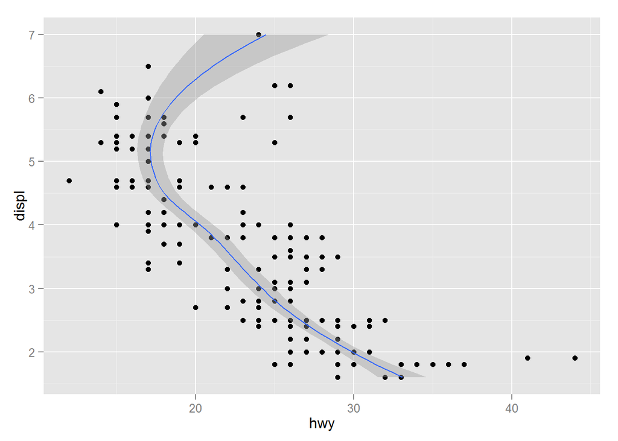

```r
ggplot(data = mpg, aes(displ, hwy)) +
  geom_point() +
  geom_smooth() +
  coord_flip() # x, y축 변경
```

```
## geom_smooth: method="auto" and size of largest group is <1000, so using loess. Use 'method = x' to change the smoothing method.
```

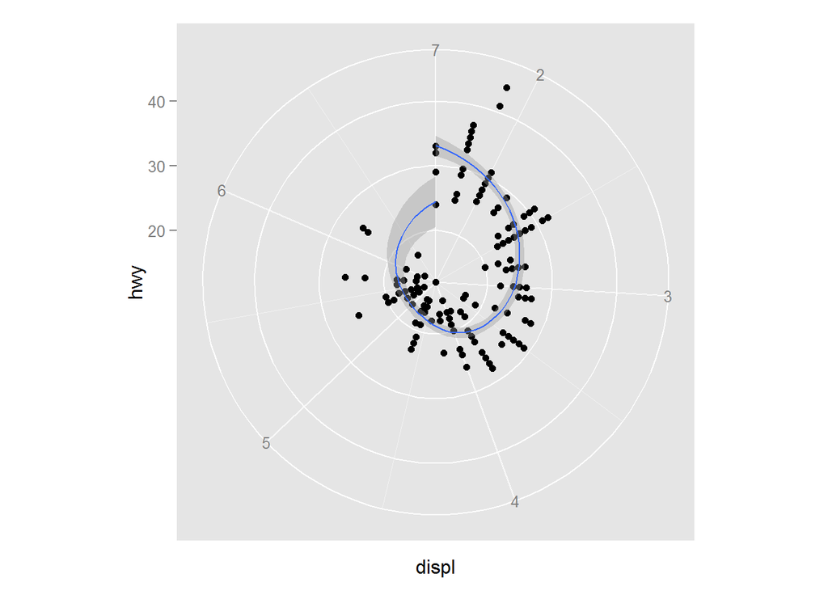

```r
ggplot(data = mpg, aes(displ, hwy)) +
  geom_point() +
  geom_smooth() +
  coord_polar()
```

## Facetting

데이터의 부분 집합들을 하위 그래프로 분리해서 그릴 수 있다

`facet_grid()`또는 `facet_wrap()`을 사용하고 분리할 변수들을 지정한다.

`facet_wrap()`을 사용하면 하위 그래프들이 수평으로 나열된다

`facet_grid()`수직과 수평으로 각각 다른 변수를 지정할 수 있다

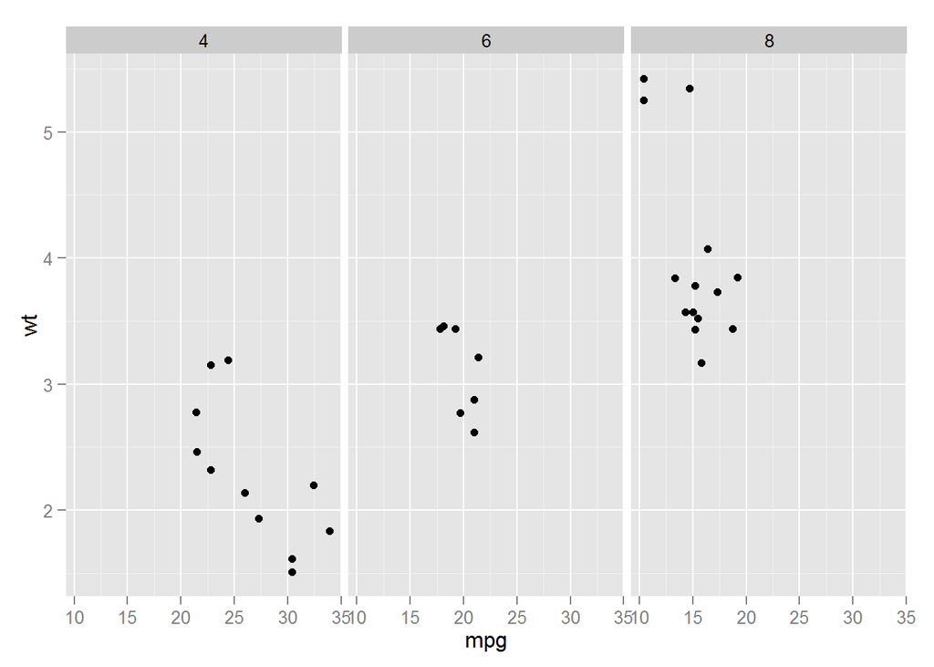

```r
mtc_point <- ggplot(mtcars, aes(mpg, wt)) + geom_point()
mtc_point +
  facet_wrap(~cyl)
```

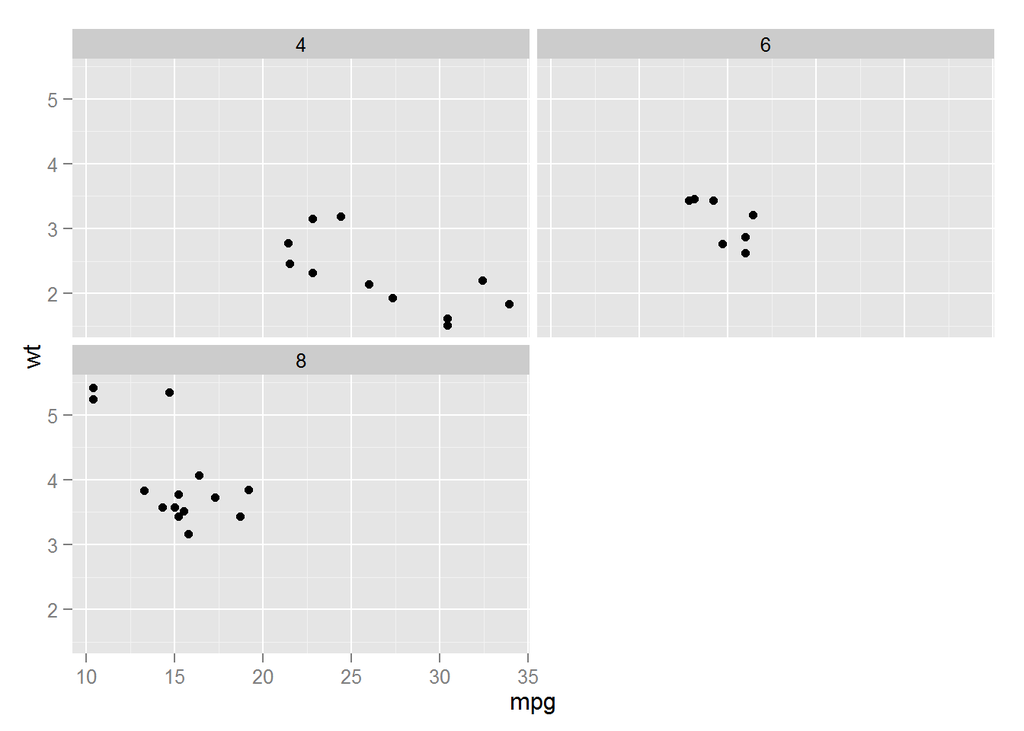

```r
mtc_point +
  facet_wrap(~cyl, ncol = 2)
```

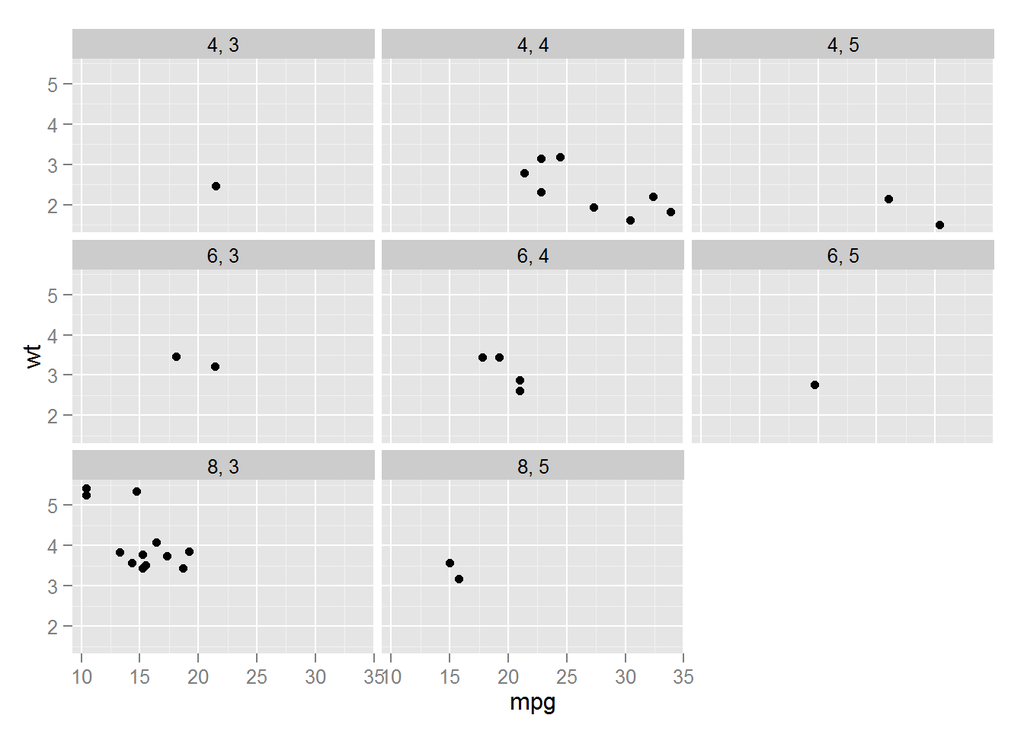

```r
mtc_point +
  facet_wrap(~cyl+gear)
```

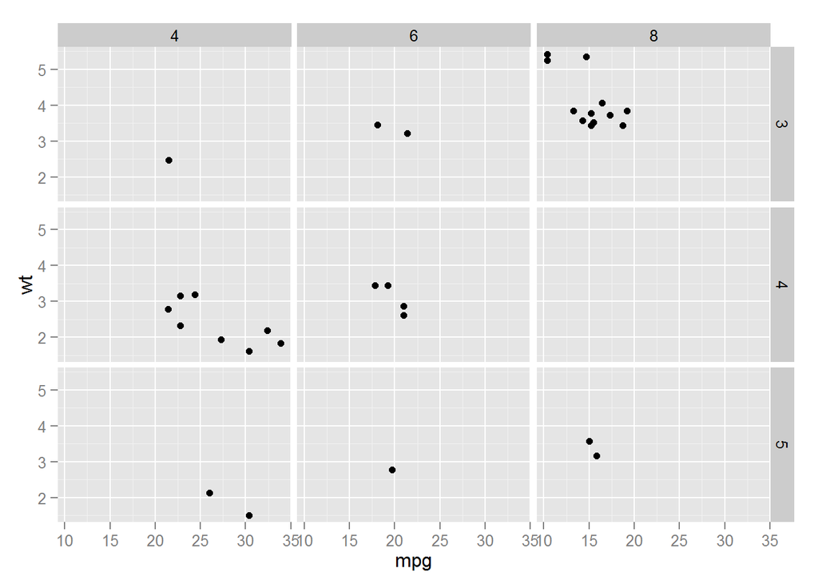

```r
mtc_point +
  facet_grid(gear~cyl)
```

`scales`옵션을 조정하면 축이 서로 다른 면을 만들 수 있다

`"free"` 는 x, y축 눈금을 모두 자유롭게하고, `"free_x"` 또는 `"free_y"`를 통해 각각의 눈금을 자유롭게 둘 수 있다

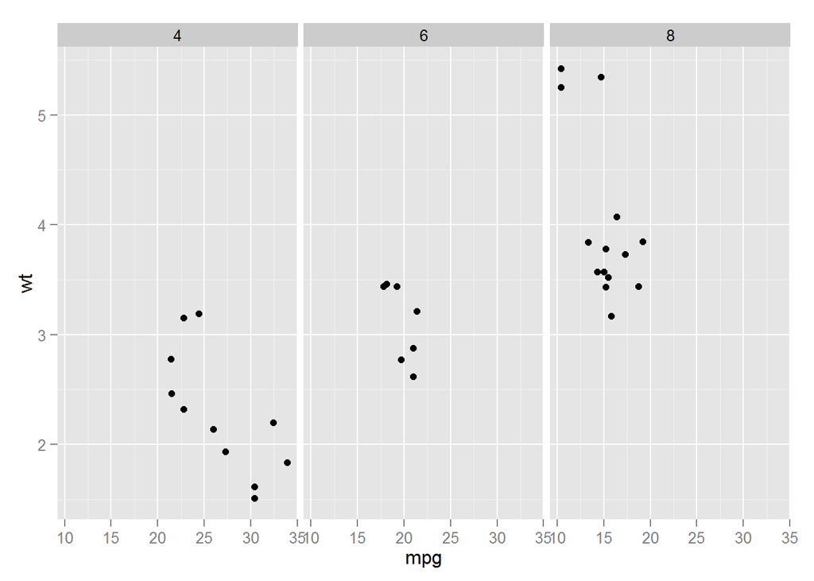

```r
mtc_point +
  facet_wrap(~cyl, scales = "fixed")
```

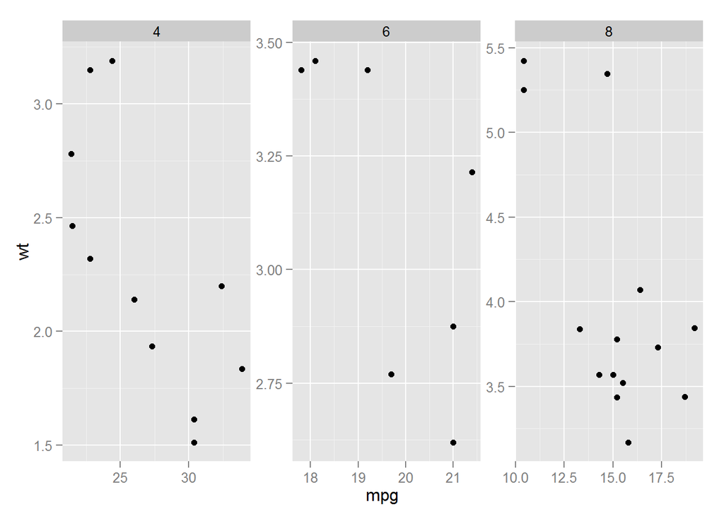

```r
mtc_point +
  facet_wrap(~cyl, scales = "free")
```

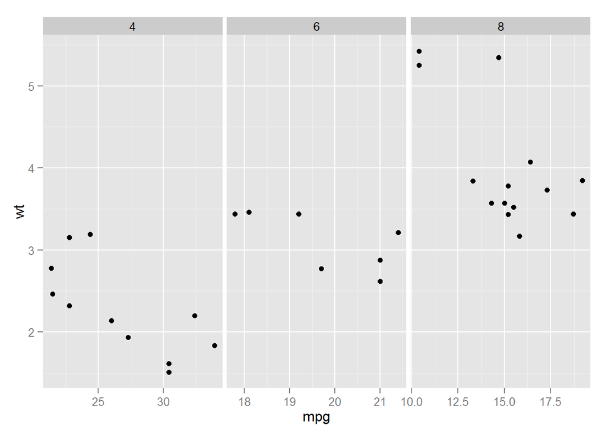

```r
mtc_point +
  facet_wrap(~cyl, scales = "free_x")
```

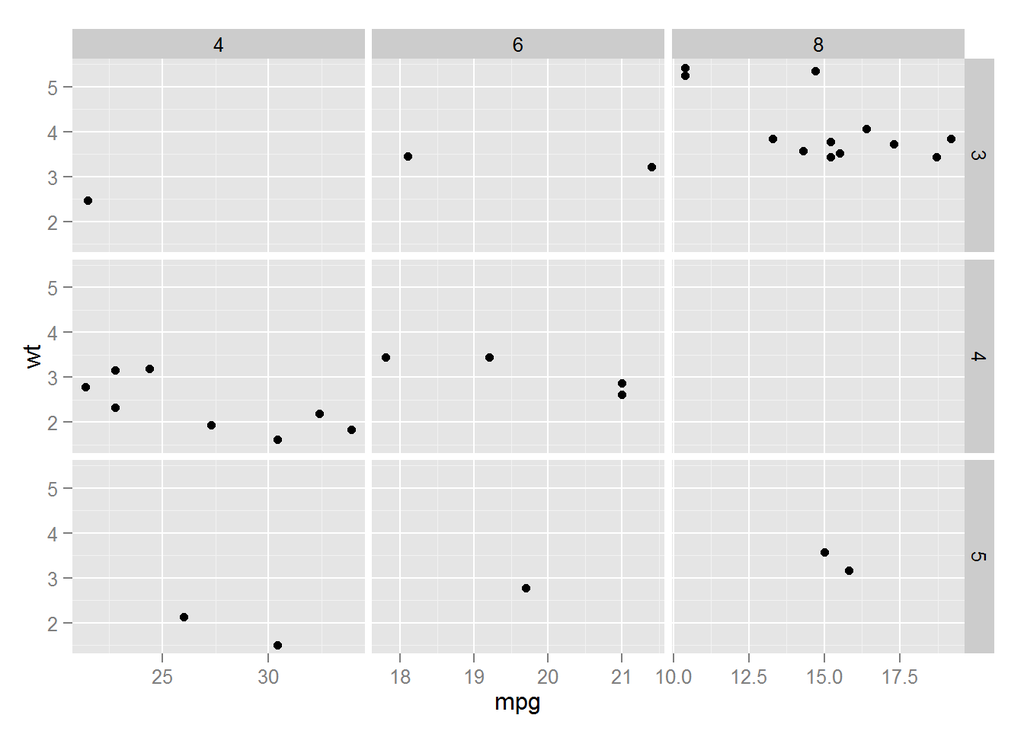

```r
mtc_point +
  facet_grid(gear~cyl, scales = "free_x")
```

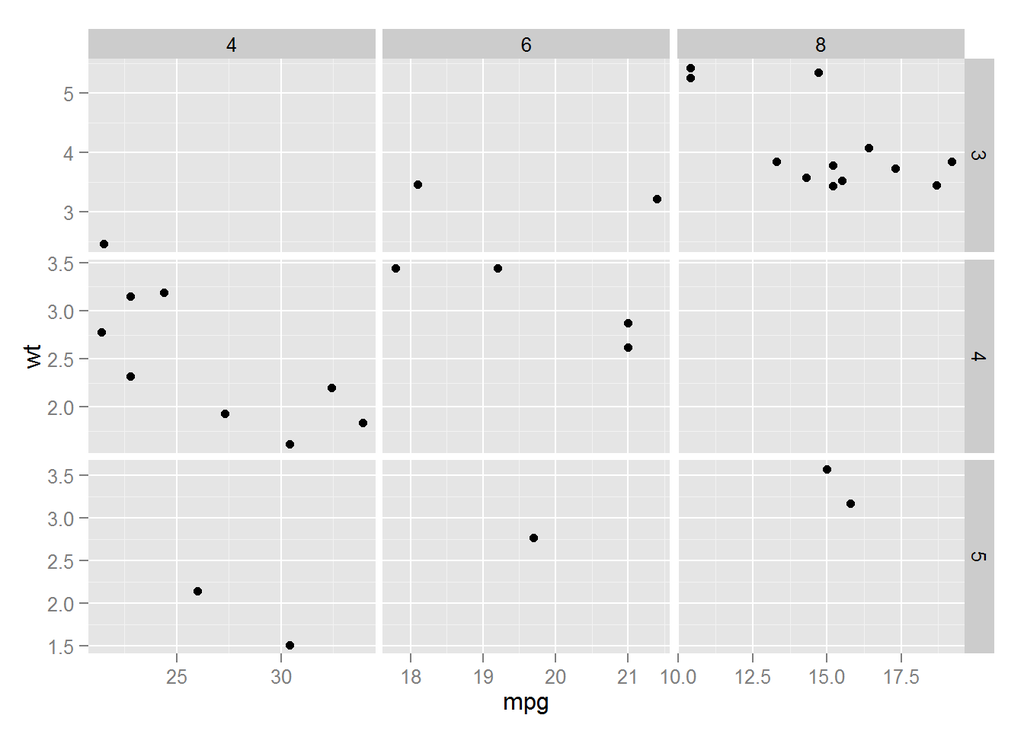

```r
mtc_point +
  facet_grid(gear~cyl, scales = "free")
```

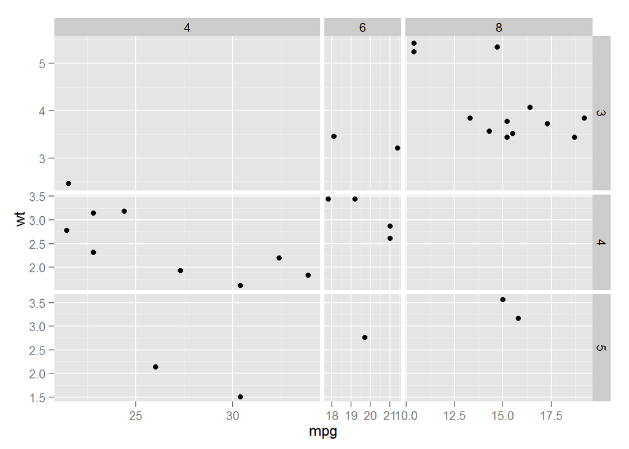

```r
mtc_point +
  facet_grid(gear~cyl, scales = "free", space = "free")
```

## theme

그래프의 세부적인 요소들을 조절해서 테마로 저장하는 것이 가능하다

기본적으로 ggplot에서 제공하는 테마도 있으며 패키지로 배포되는 테마들도 있다

아래 예제에서는 ggplot2의 기본 테마와 `ggthemes` 패키지의 테마를 일부 적용해보았다

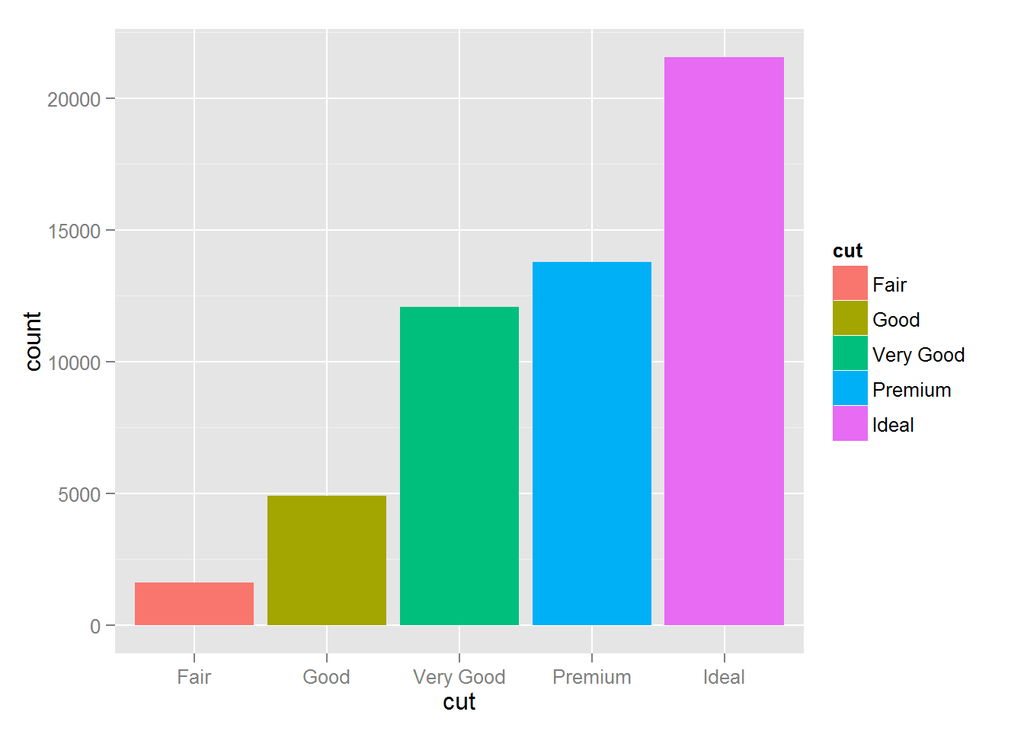

```r
dia_bar + theme_gray()
```

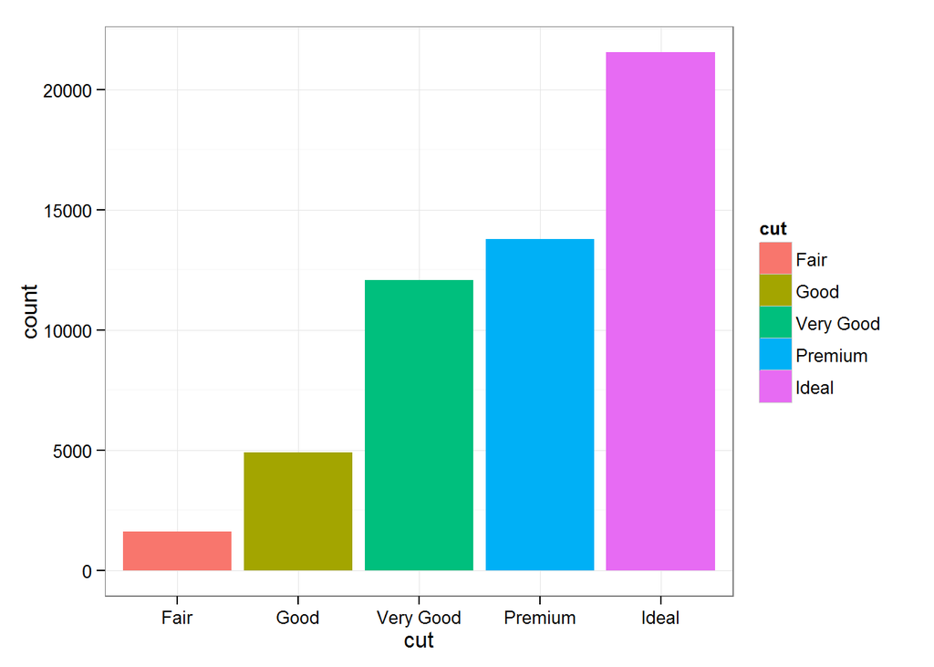

```r
dia_bar + theme_bw()
```

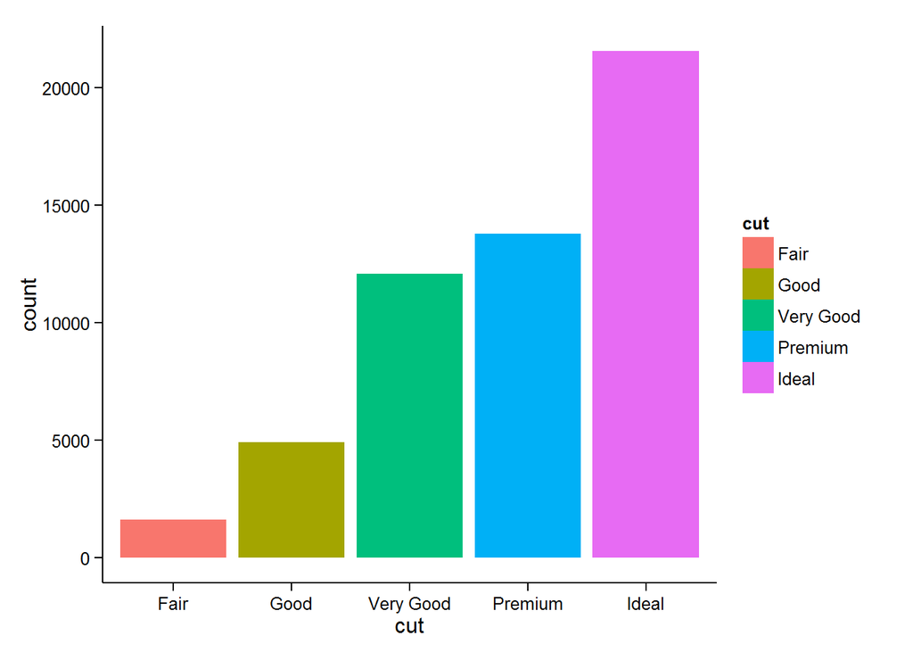

```r
dia_bar + theme_classic()
```

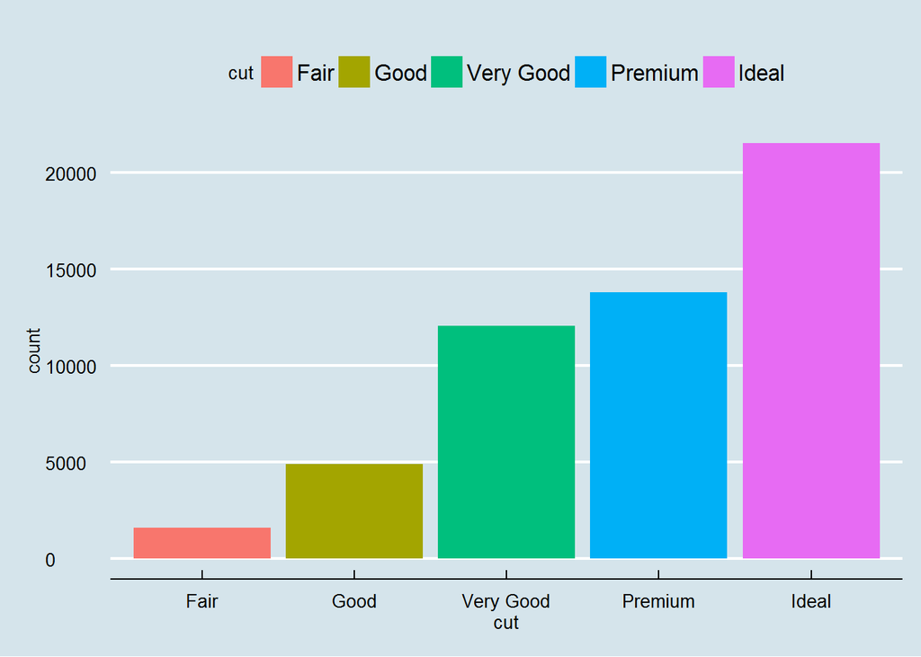

```r
# install.packages("ggthemes")
library(ggthemes)
dia_bar + theme_economist() + scale_colour_economist()
```

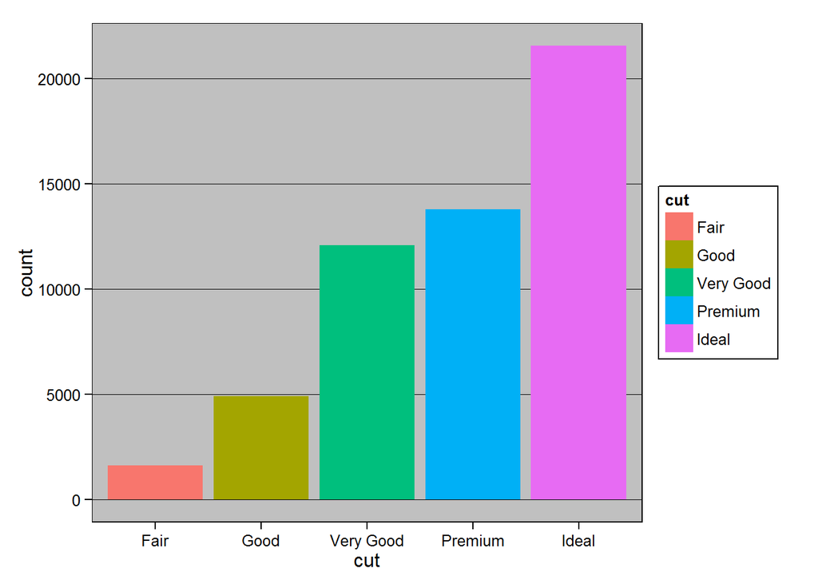

```r
dia_bar + theme_excel()
```

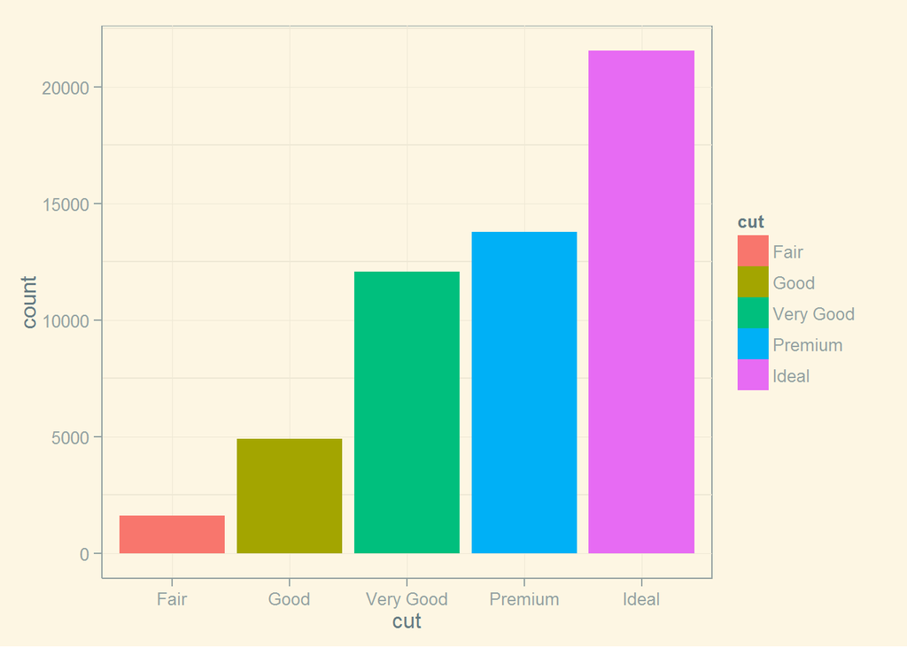

```r
dia_bar + theme_solarized()
```

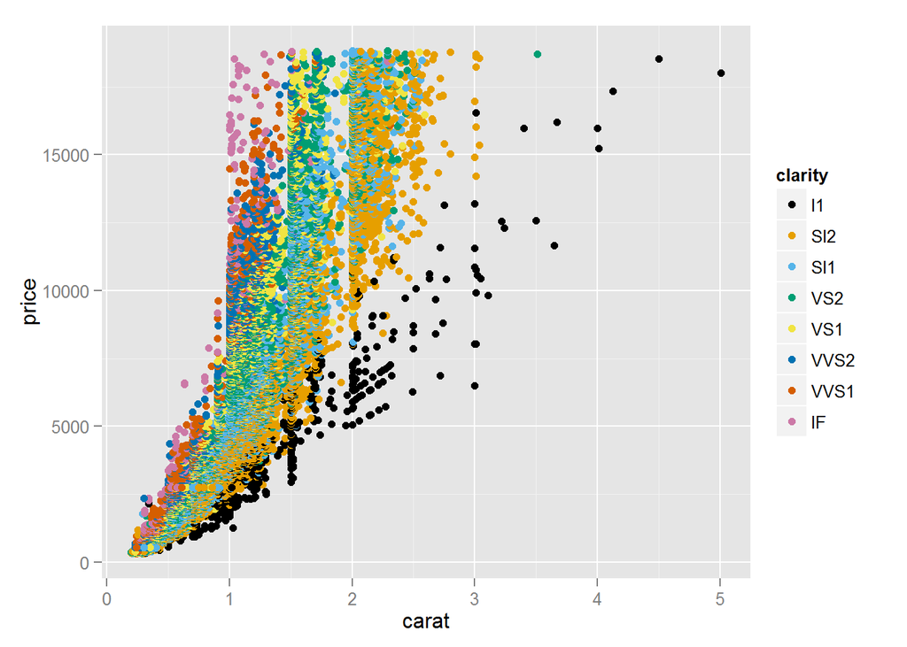

```r
ggplot(diamonds, aes(x = carat, y = price, colour = clarity)) +
  geom_point() +
  scale_colour_colorblind() # 색각이상자를 위한 색조합
```